# L’apprentissage non supervisé

## Implémentation d’une méthode de clustering avec Python

Dans le cas d’un clustering les données consiste en un bloc de variables x desquelles on va extraire des groupes d’observations.

Nous allons appliquer les k-means directement sur les données. Les k-means (k-moyennes) sont donc un algorithme d’apprentissage non supervisé permettant de construire des classes d’observations à partir d’un jeu de données de grande dimension.

## Préparation des données

Les données que nous utilisons sont des données sur les communes d’Île-de- France et leur caractéristiques socio-démographiques.

Notre objectif est ici de comprendre s’il existe des classes de communes ayant des caractéristiques proches. On obtiendra ainsi une typologie des communes d’Île-de-France et on pourra représenter ces groupes sur une carte.

Nous allons préparer ces données qui sont disponibles sur le site du livre. Une description est disponible au début du chapitre 4.m

```python
import pandas as pd
import numpy as np
# on récupère le fichier csv
data=pd.read_csv("../data/base-comparateur-de-territoires.csv",sep=";")
# on enlève des variables avec trop de données manquantes
data.drop(["PIMP14","TP6014"],axis=1,inplace=True)
# on enlève les observations avec des données manquantes
data.dropna(inplace=True)
# on extrait dans un DataFrame la position géographique des comunes
position=pd.DataFrame(data["geo_point_2d"])
# on crée une colonne longitude en prenant la première partie
# de la colonne geo_point_2
position["longitude"]=pd.to_numeric(position["geo_point_2d"].str.split(',')\
                                    .str.get(0))
# on fait la même chose pour la latitude
position["latitude"]=pd.to_numeric(position["geo_point_2d"].str.split(',')\
                                   .str.get(1))
# finalement, on sélectionne uniquement les données numériques
# pour faire notre K-means et on enlève trois variables inutiles
x=data.select_dtypes(np.number).drop(["CODGEO","REG","DEP"],axis=1)
```

## Validation du modèle et choix du nombre de classes

Dans le cas du clustering, il est très difficile de valider le modèle avec des indicateurs statistiques. En effet, on ne peut pas tester la qualité prédictive. Nous allons essayer de faire en sorte d’obtenir des classes les plus homogènes possibles et de minimiser l’inertie.

Afin de choisir le nombre de classe à utiliser on peut utiliser un graphique. Elle représente l’inertie par nombre de classes. On recherche un coude dans cette courbe pour décider le nombre à retenir.

```python
from sklearn.cluster import KMeans
import matplotlib.pyplot as plt
%matplotlib inline
```

```python
# on crée une liste dans laquelle on stocke les inerties
inerties=[]
# on fait une boucle de 2 à 9 pour tester toutes ces possibiliéts
for k in range(2, 10):
    # pour chaque k, on crée un modèle et on l’ajuste
    kmeans=KMeans(n_clusters=k)
    kmeans.fit(x)
    # on stocke l’inertie associée
    inerties.append(kmeans.inertia_)
```

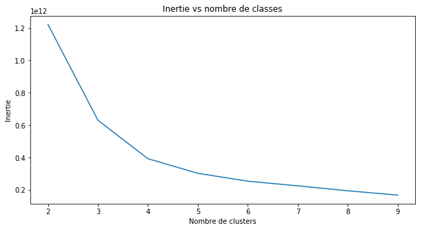

```python
# on représente le graphique
fig=plt.figure(figsize=(10, 5))
plt.plot(range(2, 10), inerties)
plt.xlabel("Nombre de clusters")
plt.ylabel("Inertie")
plt.title('Inertie vs nombre de classes')
plt.savefig("elbow.png")
```

## Application des k-means

Pour appliquer les k-means sur nos données, on utilisera :

```python
from sklearn.cluster import KMeans
modele_km=KMeans(n_clusters=4)
modele_km.fit(x)
```

```
KMeans(algorithm='auto', copy_x=True, init='k-means++', max_iter=300,
    n_clusters=4, n_init=10, n_jobs=None, precompute_distances='auto',
    random_state=None, tol=0.0001, verbose=0)
```

```python
# on stocke les classes d’appartenance dans classes
classes=modele_km.labels_
# on crée un DataFrame avec le nombre d’individus par calsse
count=pd.DataFrame(np.unique(classes,return_counts=True)[1],
columns=["Nombre d’individus"])
# on stocke les centres des classes dans un DataFrame
centres=pd.DataFrame(modele_km.cluster_centers_,columns=x.columns)
# on affiche le DataFrame avec les deux informations
pd.set_option('precision',2)
print(pd.concat([count,pd.DataFrame(centres,columns=x.columns)],axis=1).T)
pd.reset_option('precision')
```

```
                           0         1         2          3
Nombre d’individus   1063.00     32.00    172.00      10.00
P14_POP              2520.14  75067.59  30048.72  177206.80
P09_POP              2438.52  73660.69  29077.12  177166.40
SUPERF                  9.48      8.29      8.59       8.21
NAIS0914              157.02   6120.00   2467.56   12244.80
DECE0914               77.66   2127.72    872.23    5637.90
P14_MEN               971.20  32671.56  12136.82   90563.71
NAISD16                30.86   1192.66    486.42    2333.60
DECESD16               17.10    428.94    181.58    1147.60
P14_LOG              1065.33  36851.11  13126.00  104668.51
P14_RP                971.20  32671.56  12136.82   90563.71
P14_RSECOCC            30.34   1688.96    232.42    6173.12
P14_LOGVAC             63.78   2490.60    756.76    7931.68
P14_RP_PROP           669.37  13125.46   5693.89   29323.08
NBMENFISC14           958.26  30785.59  11736.59   82067.90
MED14               25363.69  25189.03  22238.60   26142.57
P14_EMPLT             756.00  53519.14  12154.64  107240.28
P14_EMPLT_SAL         662.39  48372.26  11006.97   92635.95
P09_EMPLT             732.02  53240.56  12126.41  108029.47
P14_POP1564          1641.37  50433.32  19756.05  123403.33
P14_CHOM1564          124.05   5228.42   2034.11   11852.98
P14_ACT1564          1253.88  38380.76  14934.71   95412.51
ETTOT15               208.70  12275.59   2707.62   31466.20
ETAZ15                  5.23     14.66      4.63      27.80
ETBE15                  9.37    358.25     95.80     797.40
ETFZ15                 25.19    833.16    285.85    1513.10
ETGU15                141.75   9936.03   1996.67   25662.30
ETGZ15                 35.38   1590.19    462.74    3482.30
ETOQ15                 27.15   1133.50    324.67    3465.60
ETTEF115               45.59   2785.53    604.03    6722.00
ETTEFP1015             12.71    731.22    166.35    1217.90
```

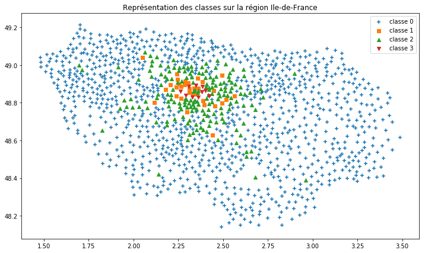

```python
# on crée une figure
plt.figure(figsize=(12,7))
# on fait une boucle sur les classes en définissant des marqueurs par classe
markers=["+","s","^","v"]
for val, mark in zip(np.unique(classes),markers):
    plt.scatter(position["latitude"][classes==val],
                position["longitude"][classes==val], marker=mark,
                label="classe% i"%(val))
plt.title("Représentation des classes sur la région Ile-de-France")
plt.legend()
plt.savefig("idf2.png")
```

[figure not shown]

On pourrait bien entendu ajouter un fond de carte comme nous l’avons fait dans le chapitre 5.

## Les mélanges gaussiens

Une méthode moins connue et alternative au k-means se nomme mélanges gaussiens. Son principe est simple : on suppose que les données sur lesquelles nous travaillons sont issues de plusieurs populations suivant des lois gaussiennes multivariées. On va donc essayer d’extraire les populations en utilisant un algorithme EM (expectation maximisation). Celui-ci utilise en plus de la moyenne et de la variance (ce qui est le cas des k-means), les structures de covariances. De plus, l’appartenance à une classe devient probabiliste.

Les mélanges gaussiens peuvent être aussi appliqués dans un cadre supervisé mais nous l’utilisons ici en non supervisé :

```python
from sklearn.mixture import GaussianMixture
modele_gmm=GaussianMixture(n_components=4)
modele_gmm.fit(x)
```

```
GaussianMixture(covariance_type='full', init_params='kmeans', max_iter=100,
        means_init=None, n_components=4, n_init=1, precisions_init=None,
        random_state=None, reg_covar=1e-06, tol=0.001, verbose=0,
        verbose_interval=10, warm_start=False, weights_init=None)
```

Nous allons obtenir des classes et des moyennes par classes :

```python
# on stocke les classes d’appartenance dans classes
classes=modele_gmm.predict(x)

# on crée un DataFrame avec le nombre d’individus par calsse
count=pd.DataFrame(np.unique(classes,return_counts=True)[1],
                   columns=["Nombre d’individus"])

# on stocke les centres des classes dans un DataFrame
centres=pd.DataFrame(modele_gmm.means_,columns=x.columns)
```

```python
# on affiche le DataFrame avec les deux informations
pd.set_option('precision',2)

print(pd.concat([count,pd.DataFrame(centres,columns=x.columns)],axis=1).T)
pd.reset_option('precision')
```

```
                           0         1          2         3
Nombre d’individus    695.00    150.00      10.00    422.00
P14_POP               759.42  41817.88  177206.80   8184.36
P09_POP               739.14  40642.72  177166.40   7926.74
SUPERF                  9.75      6.93       8.21      9.49
NAIS0914               41.22   3499.76   12244.80    554.02
DECE0914               22.56   1175.87    5637.90    257.76
P14_MEN               286.20  17397.03   90563.71   3219.68
NAISD16                 7.82    690.90    2333.60    108.08
DECESD16                5.09    242.67    1147.60     55.07
P14_LOG               328.23  19171.89  104668.51   3476.91
P14_RP                286.20  17397.03   90563.71   3219.68
P14_RSECOCC            21.03    585.10    6173.12     56.54
P14_LOGVAC             21.00   1189.77    7931.68    200.68
P14_RP_PROP           240.54   7317.41   29323.08   2008.78
NBMENFISC14           283.26  16602.85   82067.90   3168.22
MED14               25340.19  22123.88   26142.57  25267.99
P14_EMPLT             122.75  23097.53  107240.28   2504.35
P14_EMPLT_SAL          94.64  20962.57   92635.95   2215.52
P09_EMPLT             118.48  22932.76  108029.47   2476.89
P14_POP1564           497.79  27839.64  123403.33   5302.76
P14_CHOM1564           31.70   2972.45   11852.98    429.57
P14_ACT1564           384.44  21046.90   95412.51   4047.22
ETTOT15                63.77   5069.38   31466.20    653.43
ETAZ15                  5.48      6.27      27.80      4.92
ETBE15                  3.15    163.00     797.40     26.73
ETFZ15                  8.87    433.02    1513.10     74.69
ETGU15                 39.02   3950.70   25662.30    455.79
ETGZ15                  8.96    767.12    3482.30    110.96
ETOQ15                  7.26    516.38    3465.60     91.30
ETTEF115               12.90   1147.99    6722.00    142.99
ETTEFP1015              2.01    314.34    1217.90     40.24
```

```python
# on crée une figure
plt.figure(figsize=(12,7))
# on fait une boucle sur les classes en définissant des marqueurs par classe
markers=["+","s","^","v"]
for val, mark in zip(np.unique(classes),markers):
    plt.scatter(position["latitude"][classes==val],
                position["longitude"][classes==val], marker=mark,
                label="classe% i"%(val))
plt.title("Représentation des classes sur la région Ile-de-France")
plt.legend()
plt.savefig("idf2.png")
```

[output not shown]

## Les méthodes de réduction de dimension

Parmi les algorithmes non supervisés, on inclut souvent des méthodes qui permettent de réduire le nombre de dimensions de vos données. Nous allons présenter l’utilisation de trois d’entre elles : l’analyse en composantes principales et deux méthodes non linéaires.

Les méthodes de réduction de dimensions se divisent en deux familles : les méthodes linéaires et les méthodes non linéaires.

### Méthodes linéaires

Il s’agit de méthodes d’analyse de données souvent bien connues. On pourra citer :

- l’analyse en composantes principales (ACP/PCA)
- l’analyse en composantes indépendantes
- la décomposition en valeurs singulières
- l’analyse factorielle
- les analyses multi-tableaux

Et pour des données qualitatives :

- l’analyse des correspondances multiples

Scikit-Learn possède de nombreuses approches mais nous allons nous concentrer sur une application de l’analyse en composantes principales.